# Risk Factor Analysis

## Outcome Variable

**Outcome Variable:** sstunted

## Predictor Variables

**Intervention Variable:** enwast

**Adjustment Set:**

- arm
- sex
- W_mage
- meducyrs
- feducyrs
- vagbrth
- single
- brthmon
- W_parity
- delta_W_mage
- delta_meducyrs
- delta_feducyrs
- delta_vagbrth
- delta_single
- delta_brthmon
- delta_W_parity

## Stratifying Variables

The analysis was stratified on these variable(s):

- agecat
- studyid
- country

## Data Summary

| agecat | studyid | country | enwast | sstunted | n_cell | n |
| --- | --- | --- | --- | --- | --- | --- |
| Birth | CMC-V-BCS-2002 | INDIA | 0 | 0 | 75 | 87 |
| Birth | CMC-V-BCS-2002 | INDIA | 0 | 1 | 0 | 87 |
| Birth | CMC-V-BCS-2002 | INDIA | 1 | 0 | 11 | 87 |
| Birth | CMC-V-BCS-2002 | INDIA | 1 | 1 | 1 | 87 |
| Birth | CMIN | BANGLADESH | 0 | 0 | 15 | 19 |
| Birth | CMIN | BANGLADESH | 0 | 1 | 0 | 19 |
| Birth | CMIN | BANGLADESH | 1 | 0 | 4 | 19 |
| Birth | CMIN | BANGLADESH | 1 | 1 | 0 | 19 |
| Birth | COHORTS | GUATEMALA | 0 | 0 | 564 | 762 |
| Birth | COHORTS | GUATEMALA | 0 | 1 | 0 | 762 |
| Birth | COHORTS | GUATEMALA | 1 | 0 | 198 | 762 |
| Birth | COHORTS | GUATEMALA | 1 | 1 | 0 | 762 |
| Birth | COHORTS | INDIA | 0 | 0 | 5097 | 6231 |
| Birth | COHORTS | INDIA | 0 | 1 | 0 | 6231 |
| Birth | COHORTS | INDIA | 1 | 0 | 1134 | 6231 |
| Birth | COHORTS | INDIA | 1 | 1 | 0 | 6231 |
| Birth | COHORTS | PHILIPPINES | 0 | 0 | 2448 | 2910 |
| Birth | COHORTS | PHILIPPINES | 0 | 1 | 0 | 2910 |
| Birth | COHORTS | PHILIPPINES | 1 | 0 | 462 | 2910 |
| Birth | COHORTS | PHILIPPINES | 1 | 1 | 0 | 2910 |
| Birth | CONTENT | PERU | 0 | 0 | 2 | 2 |
| Birth | CONTENT | PERU | 0 | 1 | 0 | 2 |
| Birth | CONTENT | PERU | 1 | 0 | 0 | 2 |
| Birth | CONTENT | PERU | 1 | 1 | 0 | 2 |
| Birth | EE | PAKISTAN | 0 | 0 | 154 | 180 |
| Birth | EE | PAKISTAN | 0 | 1 | 1 | 180 |
| Birth | EE | PAKISTAN | 1 | 0 | 25 | 180 |
| Birth | EE | PAKISTAN | 1 | 1 | 0 | 180 |
| Birth | GMS-Nepal | NEPAL | 0 | 0 | 509 | 645 |
| Birth | GMS-Nepal | NEPAL | 0 | 1 | 0 | 645 |

[output cut: 298 more lines]

The following strata were considered:

- agecat: 24 months, studyid: CMC-V-BCS-2002, country: INDIA
- agecat: 24 months, studyid: CMIN, country: BANGLADESH
- agecat: 24 months, studyid: COHORTS, country: GUATEMALA
- agecat: 24 months, studyid: COHORTS, country: INDIA
- agecat: 24 months, studyid: COHORTS, country: PHILIPPINES
- agecat: 24 months, studyid: CONTENT, country: PERU
- agecat: 24 months, studyid: EE, country: PAKISTAN
- agecat: 24 months, studyid: GMS-Nepal, country: NEPAL
- agecat: 24 months, studyid: IRC, country: INDIA
- agecat: 24 months, studyid: JiVitA-3, country: BANGLADESH
- agecat: 24 months, studyid: JiVitA-4, country: BANGLADESH
- agecat: 24 months, studyid: Keneba, country: GAMBIA
- agecat: 24 months, studyid: LCNI-5, country: MALAWI
- agecat: 24 months, studyid: MAL-ED, country: BANGLADESH
- agecat: 24 months, studyid: MAL-ED, country: BRAZIL
- agecat: 24 months, studyid: MAL-ED, country: INDIA
- agecat: 24 months, studyid: MAL-ED, country: NEPAL
- agecat: 24 months, studyid: MAL-ED, country: PERU
- agecat: 24 months, studyid: MAL-ED, country: SOUTH AFRICA
- agecat: 24 months, studyid: MAL-ED, country: TANZANIA, UNITED REPUBLIC OF
- agecat: 24 months, studyid: NIH-Birth, country: BANGLADESH
- agecat: 24 months, studyid: NIH-Crypto, country: BANGLADESH
- agecat: 24 months, studyid: PROBIT, country: BELARUS
- agecat: 24 months, studyid: PROVIDE, country: BANGLADESH
- agecat: 24 months, studyid: TanzaniaChild2, country: TANZANIA, UNITED REPUBLIC OF
- agecat: 24 months, studyid: ZVITAMBO, country: ZIMBABWE
- agecat: 6 months, studyid: CMC-V-BCS-2002, country: INDIA
- agecat: 6 months, studyid: CMIN, country: BANGLADESH
- agecat: 6 months, studyid: COHORTS, country: GUATEMALA
- agecat: 6 months, studyid: COHORTS, country: INDIA
- agecat: 6 months, studyid: COHORTS, country: PHILIPPINES
- agecat: 6 months, studyid: CONTENT, country: PERU
- agecat: 6 months, studyid: EE, country: PAKISTAN
- agecat: 6 months, studyid: GMS-Nepal, country: NEPAL
- agecat: 6 months, studyid: Guatemala BSC, country: GUATEMALA
- agecat: 6 months, studyid: IRC, country: INDIA
- agecat: 6 months, studyid: JiVitA-3, country: BANGLADESH
- agecat: 6 months, studyid: JiVitA-4, country: BANGLADESH
- agecat: 6 months, studyid: Keneba, country: GAMBIA
- agecat: 6 months, studyid: LCNI-5, country: MALAWI
- agecat: 6 months, studyid: MAL-ED, country: BANGLADESH
- agecat: 6 months, studyid: MAL-ED, country: BRAZIL
- agecat: 6 months, studyid: MAL-ED, country: INDIA
- agecat: 6 months, studyid: MAL-ED, country: NEPAL
- agecat: 6 months, studyid: MAL-ED, country: PERU
- agecat: 6 months, studyid: MAL-ED, country: SOUTH AFRICA
- agecat: 6 months, studyid: MAL-ED, country: TANZANIA, UNITED REPUBLIC OF
- agecat: 6 months, studyid: NIH-Birth, country: BANGLADESH
- agecat: 6 months, studyid: NIH-Crypto, country: BANGLADESH
- agecat: 6 months, studyid: PROBIT, country: BELARUS
- agecat: 6 months, studyid: PROVIDE, country: BANGLADESH
- agecat: 6 months, studyid: ResPak, country: PAKISTAN
- agecat: 6 months, studyid: SAS-CompFeed, country: INDIA
- agecat: 6 months, studyid: SAS-FoodSuppl, country: INDIA
- agecat: 6 months, studyid: TanzaniaChild2, country: TANZANIA, UNITED REPUBLIC OF
- agecat: 6 months, studyid: ZVITAMBO, country: ZIMBABWE
- agecat: Birth, studyid: CMC-V-BCS-2002, country: INDIA
- agecat: Birth, studyid: CMIN, country: BANGLADESH
- agecat: Birth, studyid: COHORTS, country: GUATEMALA
- agecat: Birth, studyid: COHORTS, country: INDIA
- agecat: Birth, studyid: COHORTS, country: PHILIPPINES
- agecat: Birth, studyid: CONTENT, country: PERU
- agecat: Birth, studyid: EE, country: PAKISTAN
- agecat: Birth, studyid: GMS-Nepal, country: NEPAL
- agecat: Birth, studyid: IRC, country: INDIA
- agecat: Birth, studyid: JiVitA-3, country: BANGLADESH
- agecat: Birth, studyid: JiVitA-4, country: BANGLADESH
- agecat: Birth, studyid: Keneba, country: GAMBIA
- agecat: Birth, studyid: MAL-ED, country: BANGLADESH
- agecat: Birth, studyid: MAL-ED, country: BRAZIL
- agecat: Birth, studyid: MAL-ED, country: INDIA
- agecat: Birth, studyid: MAL-ED, country: NEPAL
- agecat: Birth, studyid: MAL-ED, country: PERU
- agecat: Birth, studyid: MAL-ED, country: SOUTH AFRICA
- agecat: Birth, studyid: MAL-ED, country: TANZANIA, UNITED REPUBLIC OF
- agecat: Birth, studyid: NIH-Birth, country: BANGLADESH
- agecat: Birth, studyid: NIH-Crypto, country: BANGLADESH
- agecat: Birth, studyid: PROBIT, country: BELARUS
- agecat: Birth, studyid: PROVIDE, country: BANGLADESH
- agecat: Birth, studyid: ResPak, country: PAKISTAN
- agecat: Birth, studyid: SAS-CompFeed, country: INDIA
- agecat: Birth, studyid: ZVITAMBO, country: ZIMBABWE

### Dropped Strata

Some strata were dropped due to rare outcomes:

- agecat: Birth, studyid: CMC-V-BCS-2002, country: INDIA
- agecat: Birth, studyid: CMIN, country: BANGLADESH
- agecat: Birth, studyid: COHORTS, country: GUATEMALA
- agecat: Birth, studyid: COHORTS, country: INDIA
- agecat: Birth, studyid: COHORTS, country: PHILIPPINES
- agecat: Birth, studyid: CONTENT, country: PERU
- agecat: Birth, studyid: EE, country: PAKISTAN
- agecat: Birth, studyid: GMS-Nepal, country: NEPAL
- agecat: Birth, studyid: IRC, country: INDIA
- agecat: Birth, studyid: JiVitA-3, country: BANGLADESH
- agecat: Birth, studyid: JiVitA-4, country: BANGLADESH
- agecat: Birth, studyid: Keneba, country: GAMBIA
- agecat: Birth, studyid: MAL-ED, country: BANGLADESH
- agecat: Birth, studyid: MAL-ED, country: BRAZIL
- agecat: Birth, studyid: MAL-ED, country: INDIA
- agecat: Birth, studyid: MAL-ED, country: NEPAL
- agecat: Birth, studyid: MAL-ED, country: PERU
- agecat: Birth, studyid: MAL-ED, country: SOUTH AFRICA
- agecat: Birth, studyid: MAL-ED, country: TANZANIA, UNITED REPUBLIC OF
- agecat: Birth, studyid: NIH-Birth, country: BANGLADESH
- agecat: Birth, studyid: NIH-Crypto, country: BANGLADESH
- agecat: Birth, studyid: PROBIT, country: BELARUS
- agecat: Birth, studyid: PROVIDE, country: BANGLADESH
- agecat: Birth, studyid: ResPak, country: PAKISTAN
- agecat: Birth, studyid: SAS-CompFeed, country: INDIA
- agecat: Birth, studyid: ZVITAMBO, country: ZIMBABWE
- agecat: 6 months, studyid: CMIN, country: BANGLADESH
- agecat: 6 months, studyid: CONTENT, country: PERU
- agecat: 6 months, studyid: GMS-Nepal, country: NEPAL
- agecat: 6 months, studyid: Guatemala BSC, country: GUATEMALA
- agecat: 6 months, studyid: MAL-ED, country: BANGLADESH
- agecat: 6 months, studyid: MAL-ED, country: BRAZIL
- agecat: 6 months, studyid: MAL-ED, country: INDIA
- agecat: 6 months, studyid: MAL-ED, country: NEPAL
- agecat: 6 months, studyid: MAL-ED, country: PERU
- agecat: 6 months, studyid: MAL-ED, country: SOUTH AFRICA
- agecat: 6 months, studyid: MAL-ED, country: TANZANIA, UNITED REPUBLIC OF
- agecat: 6 months, studyid: TanzaniaChild2, country: TANZANIA, UNITED REPUBLIC OF
- agecat: 24 months, studyid: CONTENT, country: PERU
- agecat: 24 months, studyid: LCNI-5, country: MALAWI
- agecat: 24 months, studyid: MAL-ED, country: BRAZIL
- agecat: 24 months, studyid: MAL-ED, country: NEPAL
- agecat: 24 months, studyid: MAL-ED, country: PERU
- agecat: 24 months, studyid: MAL-ED, country: SOUTH AFRICA
- agecat: 24 months, studyid: MAL-ED, country: TANZANIA, UNITED REPUBLIC OF
- agecat: 24 months, studyid: TanzaniaChild2, country: TANZANIA, UNITED REPUBLIC OF

## Methods Detail

We’re interested in the causal parameters $E[Y_a]$ for all values of $a \in \mathcal{A}$. These parameters represent the mean outcome if, possibly contrary to fact, we intervened to set all units to have $A=a$. Under the randomization and positivity assumptions, these are identified by the statistical parameters $\psi_a=E_W[E_{Y|A,W}(Y|A=a,W)]$. In addition, we’re interested in the mean of $Y$, $E[Y]$ under no intervention (the observed mean). We will estimate these parameters by using SuperLearner to fit the relevant likelihood factors – $E_{Y|A,W}(Y|A=a,W)$ and $p(A=a|W)$, and then updating our likelihood fit using a joint TMLE.

For unadjusted analyses ($W=\{\}$), initial likelihoods were estimated using Lrnr_glm to estimate the simple $E(Y|A)$ and Lrnr_mean to estimate $p(A)$. For adjusted analyses, a small library containing Lrnr_glmnet, Lrnr_xgboost, and Lrnr_mean was used.

Having estimated these parameters, we will then use the delta method to estimate relative risks and attributable risks relative to a prespecified baseline level of $A$.

# Results Detail

## Results Plots

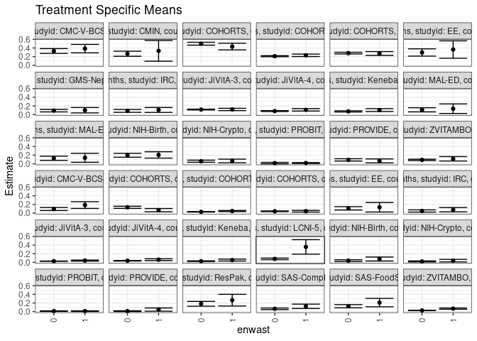

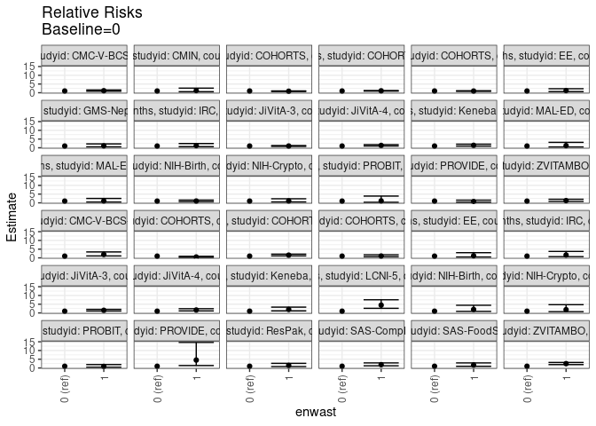

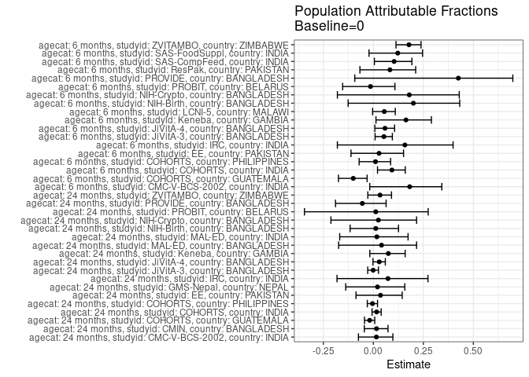

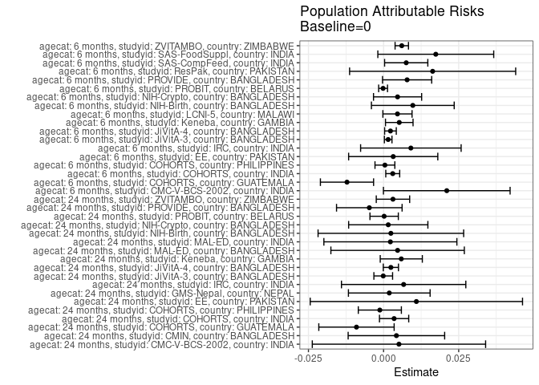

## Results Table

### Parameter: TSM

| agecat | studyid | country | intervention_level | baseline_level | estimate | ci_lower | ci_upper |
| --- | --- | --- | --- | --- | --- | --- | --- |
| 6 months | CMC-V-BCS-2002 | INDIA | 0 | NA | 0.0946698 | 0.0593947 | 0.1299448 |
| 6 months | CMC-V-BCS-2002 | INDIA | 1 | NA | 0.1850301 | 0.1075629 | 0.2624973 |
| 6 months | COHORTS | GUATEMALA | 0 | NA | 0.1331479 | 0.1084298 | 0.1578660 |
| 6 months | COHORTS | GUATEMALA | 1 | NA | 0.0684109 | 0.0314941 | 0.1053278 |
| 6 months | COHORTS | INDIA | 0 | NA | 0.0298317 | 0.0252901 | 0.0343732 |
| 6 months | COHORTS | INDIA | 1 | NA | 0.0468086 | 0.0344929 | 0.0591243 |
| 6 months | COHORTS | PHILIPPINES | 0 | NA | 0.0415888 | 0.0332336 | 0.0499439 |
| 6 months | COHORTS | PHILIPPINES | 1 | NA | 0.0442957 | 0.0240006 | 0.0645909 |
| 6 months | EE | PAKISTAN | 0 | NA | 0.1098039 | 0.0713647 | 0.1482432 |
| 6 months | EE | PAKISTAN | 1 | NA | 0.1351351 | 0.0247907 | 0.2454796 |
| 6 months | IRC | INDIA | 0 | NA | 0.0485075 | 0.0227527 | 0.0742622 |
| 6 months | IRC | INDIA | 1 | NA | 0.0789474 | 0.0293823 | 0.1285125 |
| 6 months | JiVitA-3 | BANGLADESH | 0 | NA | 0.0275316 | 0.0244575 | 0.0306057 |
| 6 months | JiVitA-3 | BANGLADESH | 1 | NA | 0.0416139 | 0.0301634 | 0.0530643 |
| 6 months | JiVitA-4 | BANGLADESH | 0 | NA | 0.0371633 | 0.0311996 | 0.0431270 |
| 6 months | JiVitA-4 | BANGLADESH | 1 | NA | 0.0626769 | 0.0420579 | 0.0832960 |
| 6 months | Keneba | GAMBIA | 0 | NA | 0.0268102 | 0.0189916 | 0.0346287 |
| 6 months | Keneba | GAMBIA | 1 | NA | 0.0531696 | 0.0305590 | 0.0757803 |
| 6 months | LCNI-5 | MALAWI | 0 | NA | 0.0800000 | 0.0613187 | 0.0986813 |
| 6 months | LCNI-5 | MALAWI | 1 | NA | 0.3571429 | 0.1895146 | 0.5247712 |
| 6 months | NIH-Birth | BANGLADESH | 0 | NA | 0.0389055 | 0.0187961 | 0.0590149 |
| 6 months | NIH-Birth | BANGLADESH | 1 | NA | 0.0772806 | 0.0311779 | 0.1233834 |
| 6 months | NIH-Crypto | BANGLADESH | 0 | NA | 0.0212766 | 0.0088287 | 0.0337245 |
| 6 months | NIH-Crypto | BANGLADESH | 1 | NA | 0.0395480 | 0.0108154 | 0.0682806 |
| 6 months | PROBIT | BELARUS | 0 | NA | 0.0112685 | 0.0049937 | 0.0175433 |
| 6 months | PROBIT | BELARUS | 1 | NA | 0.0105014 | 0.0032936 | 0.0177092 |
| 6 months | PROVIDE | BANGLADESH | 0 | NA | 0.0105932 | 0.0013496 | 0.0198369 |
| 6 months | PROVIDE | BANGLADESH | 1 | NA | 0.0480000 | 0.0104944 | 0.0855056 |
| 6 months | ResPak | PAKISTAN | 0 | NA | 0.1810381 | 0.1256034 | 0.2364728 |
| 6 months | ResPak | PAKISTAN | 1 | NA | 0.2650688 | 0.1298738 | 0.4002639 |
| 6 months | SAS-CompFeed | INDIA | 0 | NA | 0.0650121 | 0.0463174 | 0.0837068 |
| 6 months | SAS-CompFeed | INDIA | 1 | NA | 0.1233652 | 0.0734241 | 0.1733062 |
| 6 months | SAS-FoodSuppl | INDIA | 0 | NA | 0.1247294 | 0.0879267 | 0.1615321 |
| 6 months | SAS-FoodSuppl | INDIA | 1 | NA | 0.2088372 | 0.1112199 | 0.3064546 |
| 6 months | ZVITAMBO | ZIMBABWE | 0 | NA | 0.0279514 | 0.0240528 | 0.0318500 |
| 6 months | ZVITAMBO | ZIMBABWE | 1 | NA | 0.0694421 | 0.0555236 | 0.0833605 |
| 24 months | CMC-V-BCS-2002 | INDIA | 0 | NA | 0.3300447 | 0.2742006 | 0.3858888 |
| 24 months | CMC-V-BCS-2002 | INDIA | 1 | NA | 0.3844180 | 0.2862077 | 0.4826282 |
| 24 months | CMIN | BANGLADESH | 0 | NA | 0.2672811 | 0.2082734 | 0.3262889 |
| 24 months | CMIN | BANGLADESH | 1 | NA | 0.3333333 | 0.0942583 | 0.5724084 |
| 24 months | COHORTS | GUATEMALA | 0 | NA | 0.4987916 | 0.4656646 | 0.5319185 |
| 24 months | COHORTS | GUATEMALA | 1 | NA | 0.4330200 | 0.3558659 | 0.5101741 |
| 24 months | COHORTS | INDIA | 0 | NA | 0.2099079 | 0.1977503 | 0.2220655 |
| 24 months | COHORTS | INDIA | 1 | NA | 0.2310095 | 0.2028493 | 0.2591696 |
| 24 months | COHORTS | PHILIPPINES | 0 | NA | 0.2811734 | 0.2614227 | 0.3009241 |
| 24 months | COHORTS | PHILIPPINES | 1 | NA | 0.2730247 | 0.2288874 | 0.3171621 |
| 24 months | EE | PAKISTAN | 0 | NA | 0.2956522 | 0.2119428 | 0.3793616 |
| 24 months | EE | PAKISTAN | 1 | NA | 0.3636364 | 0.1618862 | 0.5653865 |
| 24 months | GMS-Nepal | NEPAL | 0 | NA | 0.0904110 | 0.0609591 | 0.1198628 |
| 24 months | GMS-Nepal | NEPAL | 1 | NA | 0.1000000 | 0.0379523 | 0.1620477 |
| 24 months | IRC | INDIA | 0 | NA | 0.0847041 | 0.0509483 | 0.1184599 |
| 24 months | IRC | INDIA | 1 | NA | 0.1058264 | 0.0490932 | 0.1625596 |
| 24 months | JiVitA-3 | BANGLADESH | 0 | NA | 0.1156851 | 0.1067061 | 0.1246642 |
| 24 months | JiVitA-3 | BANGLADESH | 1 | NA | 0.1174128 | 0.0904796 | 0.1443461 |
| 24 months | JiVitA-4 | BANGLADESH | 0 | NA | 0.0803031 | 0.0703698 | 0.0902364 |
| 24 months | JiVitA-4 | BANGLADESH | 1 | NA | 0.1088016 | 0.0803671 | 0.1372362 |
| 24 months | Keneba | GAMBIA | 0 | NA | 0.0728162 | 0.0589701 | 0.0866623 |
| 24 months | Keneba | GAMBIA | 1 | NA | 0.1029995 | 0.0695582 | 0.1364407 |
| 24 months | MAL-ED | BANGLADESH | 0 | NA | 0.1097561 | 0.0617962 | 0.1577160 |
| 24 months | MAL-ED | BANGLADESH | 1 | NA | 0.1351351 | 0.0247048 | 0.2455655 |
| 24 months | MAL-ED | INDIA | 0 | NA | 0.1277778 | 0.0788980 | 0.1766575 |
| 24 months | MAL-ED | INDIA | 1 | NA | 0.1395349 | 0.0357348 | 0.2433350 |
| 24 months | NIH-Birth | BANGLADESH | 0 | NA | 0.1980602 | 0.1524195 | 0.2437009 |
| 24 months | NIH-Birth | BANGLADESH | 1 | NA | 0.2053432 | 0.1314661 | 0.2792202 |
| 24 months | NIH-Crypto | BANGLADESH | 0 | NA | 0.0604396 | 0.0359345 | 0.0849446 |
| 24 months | NIH-Crypto | BANGLADESH | 1 | NA | 0.0661765 | 0.0243552 | 0.1079978 |
| 24 months | PROBIT | BELARUS | 0 | NA | 0.0156813 | -0.0010376 | 0.0324003 |
| 24 months | PROBIT | BELARUS | 1 | NA | 0.0175743 | 0.0058872 | 0.0292614 |
| 24 months | PROVIDE | BANGLADESH | 0 | NA | 0.0907080 | 0.0642087 | 0.1172073 |
| 24 months | PROVIDE | BANGLADESH | 1 | NA | 0.0677966 | 0.0223975 | 0.1131958 |
| 24 months | ZVITAMBO | ZIMBABWE | 0 | NA | 0.0905594 | 0.0752161 | 0.1059027 |
| 24 months | ZVITAMBO | ZIMBABWE | 1 | NA | 0.1157792 | 0.0646865 | 0.1668719 |

### Parameter: E(Y)

| agecat | studyid | country | intervention_level | baseline_level | estimate | ci_lower | ci_upper |
| --- | --- | --- | --- | --- | --- | --- | --- |
| 6 months | CMC-V-BCS-2002 | INDIA | NA | NA | 0.1157025 | 0.0827518 | 0.1486532 |
| 6 months | COHORTS | GUATEMALA | NA | NA | 0.1209767 | 0.0996719 | 0.1422815 |
| 6 months | COHORTS | INDIA | NA | NA | 0.0328826 | 0.0285497 | 0.0372155 |
| 6 months | COHORTS | PHILIPPINES | NA | NA | 0.0420363 | 0.0343109 | 0.0497616 |
| 6 months | EE | PAKISTAN | NA | NA | 0.1130137 | 0.0766368 | 0.1493906 |
| 6 months | IRC | INDIA | NA | NA | 0.0575916 | 0.0341987 | 0.0809846 |
| 6 months | JiVitA-3 | BANGLADESH | NA | NA | 0.0290649 | 0.0261073 | 0.0320225 |
| 6 months | JiVitA-4 | BANGLADESH | NA | NA | 0.0394558 | 0.0337069 | 0.0452047 |
| 6 months | Keneba | GAMBIA | NA | NA | 0.0320355 | 0.0243714 | 0.0396996 |
| 6 months | LCNI-5 | MALAWI | NA | NA | 0.0846246 | 0.0657805 | 0.1034686 |
| 6 months | NIH-Birth | BANGLADESH | NA | NA | 0.0486381 | 0.0300237 | 0.0672526 |
| 6 months | NIH-Crypto | BANGLADESH | NA | NA | 0.0259366 | 0.0141026 | 0.0377706 |
| 6 months | PROBIT | BELARUS | NA | NA | 0.0111090 | 0.0054740 | 0.0167440 |
| 6 months | PROVIDE | BANGLADESH | NA | NA | 0.0184255 | 0.0076286 | 0.0292223 |
| 6 months | ResPak | PAKISTAN | NA | NA | 0.1973684 | 0.1455920 | 0.2491449 |
| 6 months | SAS-CompFeed | INDIA | NA | NA | 0.0725474 | 0.0527677 | 0.0923271 |
| 6 months | SAS-FoodSuppl | INDIA | NA | NA | 0.1421053 | 0.1069532 | 0.1772573 |
| 6 months | ZVITAMBO | ZIMBABWE | NA | NA | 0.0340103 | 0.0300807 | 0.0379399 |
| 24 months | CMC-V-BCS-2002 | INDIA | NA | NA | 0.3351648 | 0.2866046 | 0.3837251 |
| 24 months | CMIN | BANGLADESH | NA | NA | 0.2715517 | 0.2141972 | 0.3289063 |
| 24 months | COHORTS | GUATEMALA | NA | NA | 0.4897760 | 0.4591879 | 0.5203642 |
| 24 months | COHORTS | INDIA | NA | NA | 0.2134122 | 0.2021332 | 0.2246912 |
| 24 months | COHORTS | PHILIPPINES | NA | NA | 0.2799318 | 0.2617643 | 0.2980994 |
| 24 months | EE | PAKISTAN | NA | NA | 0.3065693 | 0.2290795 | 0.3840591 |
| 24 months | GMS-Nepal | NEPAL | NA | NA | 0.0923077 | 0.0656815 | 0.1189338 |
| 24 months | IRC | INDIA | NA | NA | 0.0913838 | 0.0624876 | 0.1202800 |
| 24 months | JiVitA-3 | BANGLADESH | NA | NA | 0.1155758 | 0.1070958 | 0.1240558 |
| 24 months | JiVitA-4 | BANGLADESH | NA | NA | 0.0827346 | 0.0732177 | 0.0922516 |
| 24 months | Keneba | GAMBIA | NA | NA | 0.0787120 | 0.0658197 | 0.0916043 |
| 24 months | MAL-ED | BANGLADESH | NA | NA | 0.1144279 | 0.0703104 | 0.1585454 |
| 24 months | MAL-ED | INDIA | NA | NA | 0.1300448 | 0.0857996 | 0.1742901 |
| 24 months | NIH-Birth | BANGLADESH | NA | NA | 0.2004890 | 0.1616404 | 0.2393376 |
| 24 months | NIH-Crypto | BANGLADESH | NA | NA | 0.0620000 | 0.0408410 | 0.0831590 |
| 24 months | PROBIT | BELARUS | NA | NA | 0.0158730 | 0.0028238 | 0.0289223 |
| 24 months | PROVIDE | BANGLADESH | NA | NA | 0.0859649 | 0.0629328 | 0.1089970 |
| 24 months | ZVITAMBO | ZIMBABWE | NA | NA | 0.0936877 | 0.0789610 | 0.1084144 |

### Parameter: RR

| agecat | studyid | country | intervention_level | baseline_level | estimate | ci_lower | ci_upper |
| --- | --- | --- | --- | --- | --- | --- | --- |
| 6 months | CMC-V-BCS-2002 | INDIA | 0 | 0 | 1.0000000 | 1.0000000 | 1.000000 |
| 6 months | CMC-V-BCS-2002 | INDIA | 1 | 0 | 1.9544789 | 1.1224893 | 3.403140 |
| 6 months | COHORTS | GUATEMALA | 0 | 0 | 1.0000000 | 1.0000000 | 1.000000 |
| 6 months | COHORTS | GUATEMALA | 1 | 0 | 0.5137965 | 0.2905612 | 0.908541 |
| 6 months | COHORTS | INDIA | 0 | 0 | 1.0000000 | 1.0000000 | 1.000000 |
| 6 months | COHORTS | INDIA | 1 | 0 | 1.5690922 | 1.1583890 | 2.125409 |
| 6 months | COHORTS | PHILIPPINES | 0 | 0 | 1.0000000 | 1.0000000 | 1.000000 |
| 6 months | COHORTS | PHILIPPINES | 1 | 0 | 1.0650893 | 0.6458548 | 1.756456 |
| 6 months | EE | PAKISTAN | 0 | 0 | 1.0000000 | 1.0000000 | 1.000000 |
| 6 months | EE | PAKISTAN | 1 | 0 | 1.2306950 | 0.5061877 | 2.992191 |
| 6 months | IRC | INDIA | 0 | 0 | 1.0000000 | 1.0000000 | 1.000000 |
| 6 months | IRC | INDIA | 1 | 0 | 1.6275304 | 0.7152181 | 3.703563 |
| 6 months | JiVitA-3 | BANGLADESH | 0 | 0 | 1.0000000 | 1.0000000 | 1.000000 |
| 6 months | JiVitA-3 | BANGLADESH | 1 | 0 | 1.5114949 | 1.1185879 | 2.042412 |
| 6 months | JiVitA-4 | BANGLADESH | 0 | 0 | 1.0000000 | 1.0000000 | 1.000000 |
| 6 months | JiVitA-4 | BANGLADESH | 1 | 0 | 1.6865291 | 1.1703770 | 2.430311 |
| 6 months | Keneba | GAMBIA | 0 | 0 | 1.0000000 | 1.0000000 | 1.000000 |
| 6 months | Keneba | GAMBIA | 1 | 0 | 1.9831879 | 1.1840619 | 3.321646 |
| 6 months | LCNI-5 | MALAWI | 0 | 0 | 1.0000000 | 1.0000000 | 1.000000 |
| 6 months | LCNI-5 | MALAWI | 1 | 0 | 4.4642857 | 2.6428796 | 7.540959 |
| 6 months | NIH-Birth | BANGLADESH | 0 | 0 | 1.0000000 | 1.0000000 | 1.000000 |
| 6 months | NIH-Birth | BANGLADESH | 1 | 0 | 1.9863677 | 0.9000767 | 4.383689 |
| 6 months | NIH-Crypto | BANGLADESH | 0 | 0 | 1.0000000 | 1.0000000 | 1.000000 |
| 6 months | NIH-Crypto | BANGLADESH | 1 | 0 | 1.8587571 | 0.7313258 | 4.724266 |
| 6 months | PROBIT | BELARUS | 0 | 0 | 1.0000000 | 1.0000000 | 1.000000 |
| 6 months | PROBIT | BELARUS | 1 | 0 | 0.9319259 | 0.4471131 | 1.942430 |
| 6 months | PROVIDE | BANGLADESH | 0 | 0 | 1.0000000 | 1.0000000 | 1.000000 |
| 6 months | PROVIDE | BANGLADESH | 1 | 0 | 4.5312000 | 1.4044963 | 14.618603 |
| 6 months | ResPak | PAKISTAN | 0 | 0 | 1.0000000 | 1.0000000 | 1.000000 |
| 6 months | ResPak | PAKISTAN | 1 | 0 | 1.4641607 | 0.8084613 | 2.651663 |
| 6 months | SAS-CompFeed | INDIA | 0 | 0 | 1.0000000 | 1.0000000 | 1.000000 |
| 6 months | SAS-CompFeed | INDIA | 1 | 0 | 1.8975727 | 1.2412171 | 2.901009 |
| 6 months | SAS-FoodSuppl | INDIA | 0 | 0 | 1.0000000 | 1.0000000 | 1.000000 |
| 6 months | SAS-FoodSuppl | INDIA | 1 | 0 | 1.6743220 | 0.9626486 | 2.912126 |
| 6 months | ZVITAMBO | ZIMBABWE | 0 | 0 | 1.0000000 | 1.0000000 | 1.000000 |
| 6 months | ZVITAMBO | ZIMBABWE | 1 | 0 | 2.4843855 | 1.9462657 | 3.171289 |
| 24 months | CMC-V-BCS-2002 | INDIA | 0 | 0 | 1.0000000 | 1.0000000 | 1.000000 |
| 24 months | CMC-V-BCS-2002 | INDIA | 1 | 0 | 1.1647451 | 0.8565937 | 1.583751 |
| 24 months | CMIN | BANGLADESH | 0 | 0 | 1.0000000 | 1.0000000 | 1.000000 |
| 24 months | CMIN | BANGLADESH | 1 | 0 | 1.2471264 | 0.5888451 | 2.641313 |
| 24 months | COHORTS | GUATEMALA | 0 | 0 | 1.0000000 | 1.0000000 | 1.000000 |
| 24 months | COHORTS | GUATEMALA | 1 | 0 | 0.8681381 | 0.7184085 | 1.049074 |
| 24 months | COHORTS | INDIA | 0 | 0 | 1.0000000 | 1.0000000 | 1.000000 |
| 24 months | COHORTS | INDIA | 1 | 0 | 1.1005278 | 0.9633667 | 1.257218 |
| 24 months | COHORTS | PHILIPPINES | 0 | 0 | 1.0000000 | 1.0000000 | 1.000000 |
| 24 months | COHORTS | PHILIPPINES | 1 | 0 | 0.9710191 | 0.8155572 | 1.156115 |
| 24 months | EE | PAKISTAN | 0 | 0 | 1.0000000 | 1.0000000 | 1.000000 |
| 24 months | EE | PAKISTAN | 1 | 0 | 1.2299465 | 0.6597384 | 2.292982 |
| 24 months | GMS-Nepal | NEPAL | 0 | 0 | 1.0000000 | 1.0000000 | 1.000000 |
| 24 months | GMS-Nepal | NEPAL | 1 | 0 | 1.1060606 | 0.5488190 | 2.229096 |
| 24 months | IRC | INDIA | 0 | 0 | 1.0000000 | 1.0000000 | 1.000000 |
| 24 months | IRC | INDIA | 1 | 0 | 1.2493651 | 0.6408549 | 2.435673 |
| 24 months | JiVitA-3 | BANGLADESH | 0 | 0 | 1.0000000 | 1.0000000 | 1.000000 |
| 24 months | JiVitA-3 | BANGLADESH | 1 | 0 | 1.0149345 | 0.7963375 | 1.293537 |
| 24 months | JiVitA-4 | BANGLADESH | 0 | 0 | 1.0000000 | 1.0000000 | 1.000000 |
| 24 months | JiVitA-4 | BANGLADESH | 1 | 0 | 1.3548869 | 1.0203847 | 1.799046 |
| 24 months | Keneba | GAMBIA | 0 | 0 | 1.0000000 | 1.0000000 | 1.000000 |
| 24 months | Keneba | GAMBIA | 1 | 0 | 1.4145137 | 0.9710770 | 2.060443 |
| 24 months | MAL-ED | BANGLADESH | 0 | 0 | 1.0000000 | 1.0000000 | 1.000000 |
| 24 months | MAL-ED | BANGLADESH | 1 | 0 | 1.2312312 | 0.4874034 | 3.110217 |
| 24 months | MAL-ED | INDIA | 0 | 0 | 1.0000000 | 1.0000000 | 1.000000 |
| 24 months | MAL-ED | INDIA | 1 | 0 | 1.0920121 | 0.4730886 | 2.520649 |
| 24 months | NIH-Birth | BANGLADESH | 0 | 0 | 1.0000000 | 1.0000000 | 1.000000 |
| 24 months | NIH-Birth | BANGLADESH | 1 | 0 | 1.0367714 | 0.6780250 | 1.585332 |
| 24 months | NIH-Crypto | BANGLADESH | 0 | 0 | 1.0000000 | 1.0000000 | 1.000000 |
| 24 months | NIH-Crypto | BANGLADESH | 1 | 0 | 1.0949198 | 0.5167665 | 2.319905 |
| 24 months | PROBIT | BELARUS | 0 | 0 | 1.0000000 | 1.0000000 | 1.000000 |
| 24 months | PROBIT | BELARUS | 1 | 0 | 1.1207124 | 0.3246034 | 3.869326 |
| 24 months | PROVIDE | BANGLADESH | 0 | 0 | 1.0000000 | 1.0000000 | 1.000000 |
| 24 months | PROVIDE | BANGLADESH | 1 | 0 | 0.7474163 | 0.3599748 | 1.551862 |
| 24 months | ZVITAMBO | ZIMBABWE | 0 | 0 | 1.0000000 | 1.0000000 | 1.000000 |
| 24 months | ZVITAMBO | ZIMBABWE | 1 | 0 | 1.2784896 | 0.7971499 | 2.050474 |

### Parameter: PAR

| agecat | studyid | country | intervention_level | baseline_level | estimate | ci_lower | ci_upper |
| --- | --- | --- | --- | --- | --- | --- | --- |
| 6 months | CMC-V-BCS-2002 | INDIA | 0 | NA | 0.0210327 | -0.0000438 | 0.0421091 |
| 6 months | COHORTS | GUATEMALA | 0 | NA | -0.0121712 | -0.0210198 | -0.0033227 |
| 6 months | COHORTS | INDIA | 0 | NA | 0.0030509 | 0.0007356 | 0.0053663 |
| 6 months | COHORTS | PHILIPPINES | 0 | NA | 0.0004475 | -0.0028558 | 0.0037508 |
| 6 months | EE | PAKISTAN | 0 | NA | 0.0032098 | -0.0116279 | 0.0180475 |
| 6 months | IRC | INDIA | 0 | NA | 0.0090842 | -0.0076438 | 0.0258121 |
| 6 months | JiVitA-3 | BANGLADESH | 0 | NA | 0.0015333 | 0.0002700 | 0.0027965 |
| 6 months | JiVitA-4 | BANGLADESH | 0 | NA | 0.0022925 | 0.0003550 | 0.0042300 |
| 6 months | Keneba | GAMBIA | 0 | NA | 0.0052253 | 0.0006388 | 0.0098118 |
| 6 months | LCNI-5 | MALAWI | 0 | NA | 0.0046246 | -0.0002290 | 0.0094781 |
| 6 months | NIH-Birth | BANGLADESH | 0 | NA | 0.0097326 | -0.0040402 | 0.0235055 |
| 6 months | NIH-Crypto | BANGLADESH | 0 | NA | 0.0046600 | -0.0033482 | 0.0126682 |
| 6 months | PROBIT | BELARUS | 0 | NA | -0.0001595 | -0.0016333 | 0.0013142 |
| 6 months | PROVIDE | BANGLADESH | 0 | NA | 0.0078322 | -0.0003475 | 0.0160119 |
| 6 months | ResPak | PAKISTAN | 0 | NA | 0.0163303 | -0.0113068 | 0.0439675 |
| 6 months | SAS-CompFeed | INDIA | 0 | NA | 0.0075353 | 0.0003446 | 0.0147261 |
| 6 months | SAS-FoodSuppl | INDIA | 0 | NA | 0.0173758 | -0.0019054 | 0.0366570 |
| 6 months | ZVITAMBO | ZIMBABWE | 0 | NA | 0.0060589 | 0.0038298 | 0.0082879 |
| 24 months | CMC-V-BCS-2002 | INDIA | 0 | NA | 0.0051201 | -0.0237193 | 0.0339596 |
| 24 months | CMIN | BANGLADESH | 0 | NA | 0.0042706 | -0.0117879 | 0.0203291 |
| 24 months | COHORTS | GUATEMALA | 0 | NA | -0.0090155 | -0.0215523 | 0.0035213 |
| 24 months | COHORTS | INDIA | 0 | NA | 0.0035043 | -0.0013618 | 0.0083704 |
| 24 months | COHORTS | PHILIPPINES | 0 | NA | -0.0012416 | -0.0084097 | 0.0059266 |
| 24 months | EE | PAKISTAN | 0 | NA | 0.0109172 | -0.0244087 | 0.0462430 |
| 24 months | GMS-Nepal | NEPAL | 0 | NA | 0.0018967 | -0.0116934 | 0.0154869 |
| 24 months | IRC | INDIA | 0 | NA | 0.0066797 | -0.0140136 | 0.0273729 |
| 24 months | JiVitA-3 | BANGLADESH | 0 | NA | -0.0001093 | -0.0032198 | 0.0030012 |
| 24 months | JiVitA-4 | BANGLADESH | 0 | NA | 0.0024315 | -0.0000936 | 0.0049567 |
| 24 months | Keneba | GAMBIA | 0 | NA | 0.0058958 | -0.0011093 | 0.0129010 |
| 24 months | MAL-ED | BANGLADESH | 0 | NA | 0.0046718 | -0.0175324 | 0.0268760 |
| 24 months | MAL-ED | INDIA | 0 | NA | 0.0022671 | -0.0198648 | 0.0243989 |
| 24 months | NIH-Birth | BANGLADESH | 0 | NA | 0.0024288 | -0.0217961 | 0.0266537 |
| 24 months | NIH-Crypto | BANGLADESH | 0 | NA | 0.0015604 | -0.0116258 | 0.0147467 |
| 24 months | PROBIT | BELARUS | 0 | NA | 0.0001917 | -0.0045294 | 0.0049128 |
| 24 months | PROVIDE | BANGLADESH | 0 | NA | -0.0047431 | -0.0156521 | 0.0061659 |
| 24 months | ZVITAMBO | ZIMBABWE | 0 | NA | 0.0031283 | -0.0024302 | 0.0086869 |

### Parameter: PAF

| agecat | studyid | country | intervention_level | baseline_level | estimate | ci_lower | ci_upper |
| --- | --- | --- | --- | --- | --- | --- | --- |
| 6 months | CMC-V-BCS-2002 | INDIA | 0 | NA | 0.1817825 | -0.0181085 | 0.3424278 |
| 6 months | COHORTS | GUATEMALA | 0 | NA | -0.1006081 | -0.1745551 | -0.0313166 |
| 6 months | COHORTS | INDIA | 0 | NA | 0.0927829 | 0.0207370 | 0.1595283 |
| 6 months | COHORTS | PHILIPPINES | 0 | NA | 0.0106453 | -0.0711357 | 0.0861824 |
| 6 months | EE | PAKISTAN | 0 | NA | 0.0284017 | -0.1118993 | 0.1509993 |
| 6 months | IRC | INDIA | 0 | NA | 0.1577341 | -0.1800814 | 0.3988449 |
| 6 months | JiVitA-3 | BANGLADESH | 0 | NA | 0.0527537 | 0.0086039 | 0.0949374 |
| 6 months | JiVitA-4 | BANGLADESH | 0 | NA | 0.0581031 | 0.0074216 | 0.1061969 |
| 6 months | Keneba | GAMBIA | 0 | NA | 0.1631101 | 0.0130251 | 0.2903723 |
| 6 months | LCNI-5 | MALAWI | 0 | NA | 0.0546479 | -0.0037528 | 0.1096507 |
| 6 months | NIH-Birth | BANGLADESH | 0 | NA | 0.2001030 | -0.1262271 | 0.4318773 |
| 6 months | NIH-Crypto | BANGLADESH | 0 | NA | 0.1796690 | -0.1798998 | 0.4296610 |
| 6 months | PROBIT | BELARUS | 0 | NA | -0.0143593 | -0.1535735 | 0.1080544 |
| 6 months | PROVIDE | BANGLADESH | 0 | NA | 0.4250770 | -0.0928713 | 0.6975523 |
| 6 months | ResPak | PAKISTAN | 0 | NA | 0.0827404 | -0.0672133 | 0.2116241 |
| 6 months | SAS-CompFeed | INDIA | 0 | NA | 0.1038675 | 0.0050794 | 0.1928467 |
| 6 months | SAS-FoodSuppl | INDIA | 0 | NA | 0.1222744 | -0.0217842 | 0.2460227 |
| 6 months | ZVITAMBO | ZIMBABWE | 0 | NA | 0.1781483 | 0.1131205 | 0.2384082 |
| 24 months | CMC-V-BCS-2002 | INDIA | 0 | NA | 0.0152765 | -0.0746101 | 0.0976444 |
| 24 months | CMIN | BANGLADESH | 0 | NA | 0.0157267 | -0.0451956 | 0.0730980 |
| 24 months | COHORTS | GUATEMALA | 0 | NA | -0.0184074 | -0.0443483 | 0.0068891 |
| 24 months | COHORTS | INDIA | 0 | NA | 0.0164204 | -0.0066393 | 0.0389520 |
| 24 months | COHORTS | PHILIPPINES | 0 | NA | -0.0044352 | -0.0303632 | 0.0208403 |
| 24 months | EE | PAKISTAN | 0 | NA | 0.0356108 | -0.0867270 | 0.1441765 |
| 24 months | GMS-Nepal | NEPAL | 0 | NA | 0.0205479 | -0.1382088 | 0.1571614 |
| 24 months | IRC | INDIA | 0 | NA | 0.0730947 | -0.1818549 | 0.2730466 |
| 24 months | JiVitA-3 | BANGLADESH | 0 | NA | -0.0009460 | -0.0282255 | 0.0256098 |
| 24 months | JiVitA-4 | BANGLADESH | 0 | NA | 0.0293897 | -0.0019333 | 0.0597334 |
| 24 months | Keneba | GAMBIA | 0 | NA | 0.0749038 | -0.0176807 | 0.1590653 |
| 24 months | MAL-ED | BANGLADESH | 0 | NA | 0.0408271 | -0.1736513 | 0.2161108 |
| 24 months | MAL-ED | INDIA | 0 | NA | 0.0174330 | -0.1682942 | 0.1736345 |
| 24 months | NIH-Birth | BANGLADESH | 0 | NA | 0.0121143 | -0.1164224 | 0.1258522 |
| 24 months | NIH-Crypto | BANGLADESH | 0 | NA | 0.0251684 | -0.2123089 | 0.2161266 |
| 24 months | PROBIT | BELARUS | 0 | NA | 0.0120750 | -0.3445891 | 0.2741309 |
| 24 months | PROVIDE | BANGLADESH | 0 | NA | -0.0551743 | -0.1892409 | 0.0637786 |
| 24 months | ZVITAMBO | ZIMBABWE | 0 | NA | 0.0333910 | -0.0276238 | 0.0907831 |